# 对上次讨论的回应

康杰锋

## 奢侈效应

我们的分析中，不管是单因素还是多因素分析，都检出了地价和生物多样性负相关的结果。

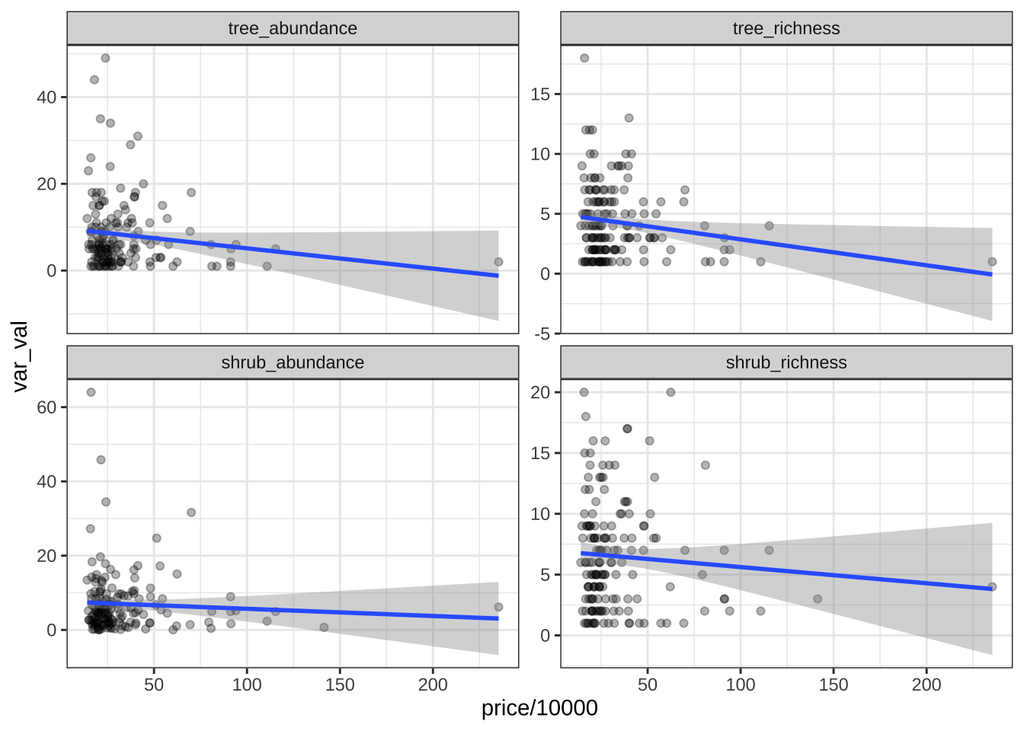

[figure not shown]

由于目前还没找到和奢侈效应（luxury effect）相反的研究结果，而且我们的研究并不是专门针对这个效应设计的，因此证据强度比较弱，所以我不知道称之为”反奢侈效应”是否合适；但是此处姑且这么称呼它。

反奢侈效应在一些研究中应该有发表过，我印象中看到过南美的一个案例，是低收入人群所在地的生物多样性反而比较高，原因可能是低收入人群种植更多品类的蔬菜水果，或者这些社区的荒地缺乏管理，因此植物种类更多。除了这样的研究结果本身较少，检索不到反奢侈效应还可能因为：如果研究者检测到收入和生物多样性相关，会觉得合情合理，直接就套上”奢侈效应”来解释；如果没有检测到显著结果，通常就不会报告；如果检测到相反的结果，就会怀疑这个结果是否正确，正如[Nature这篇文章](https://www.nature.com/articles/s42949-023-00128-7#Sec2)所说，奢侈效应和legacy effect都会受到其他因子的干扰，即使我们的分析中已经把其他因子加进去，做了广义线性回归。

上一次提到，为了理解我们检测到的反奢侈效应，先把不同低价的样地挑出来，看看有什么差别。那么我们首先看看，不同地价水平样地对应的其他因子的差异。

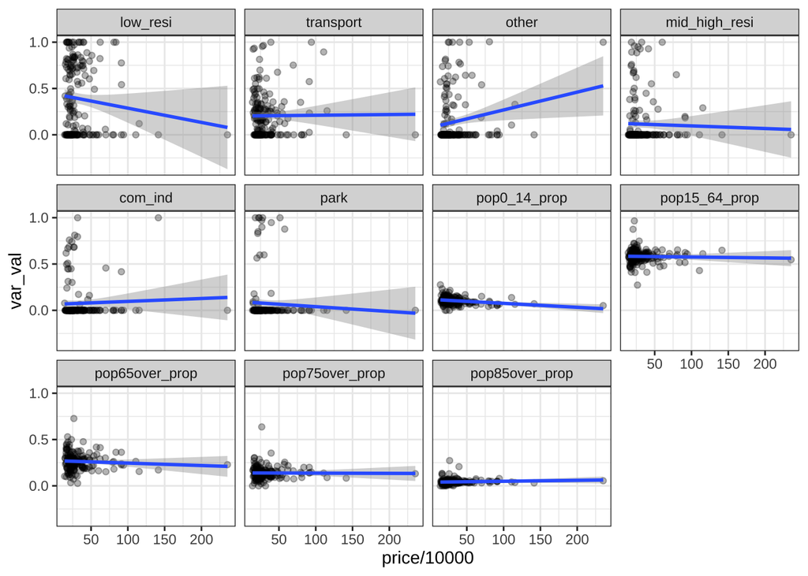

同样地，由于地价多集中于125万以内，所以先忽略特别高地价的样地，则图片变成下面这样。可见不同地价水平下，样地内的各个人口结构变量差异不大，而土地占比则略有差异：随着地价升高，地层住宅用地占比减少，交通用地占比增加，尽管这种**变化非常微妙**。如果结合单因素相关分析结果，我们发现，地价唯一影响到的生物多样性指数是tree richness，而地层住宅用地占比和tree richness呈正相关（尽管不显著），交通用地和tree richness呈负相关（也不显著），所以**可以猜测**，或许正是这两个因素导致了地价和tree richness的负相关。

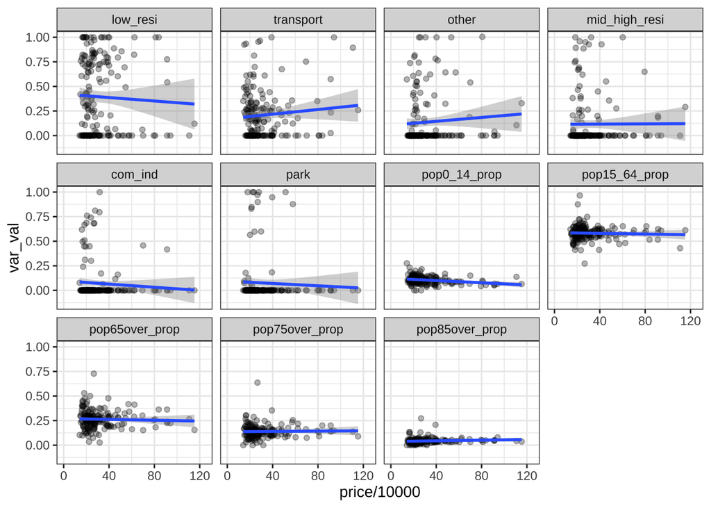

我还附上了各个调查样地的卫星图片，以及各个样地的地价（地价是”price”列，从低到高排列）表格，你可以浏览一下，看看能不能发现什么有价值的点。各个样点在地图上的分布如下图，地价用颜色表示；也可以将图层改成卫星图查看各个样地大概长什么样，但是不如发给你的卫星图片详细就是了。

[interactive chart not shown]

## 多样性地图

根据上次讨论，参考海南论文，作京都市各样点多样性大小地图。

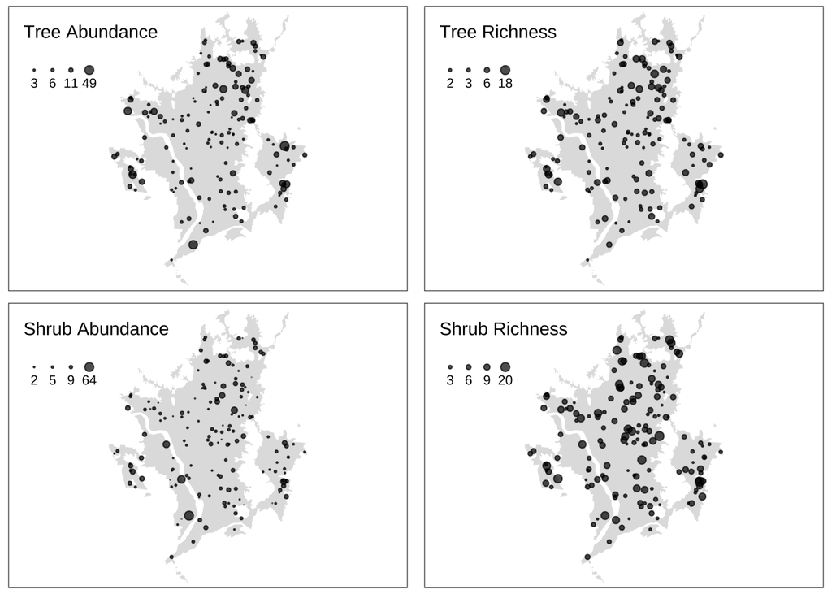

此外，作为参考，提供各个指数的分布情况。

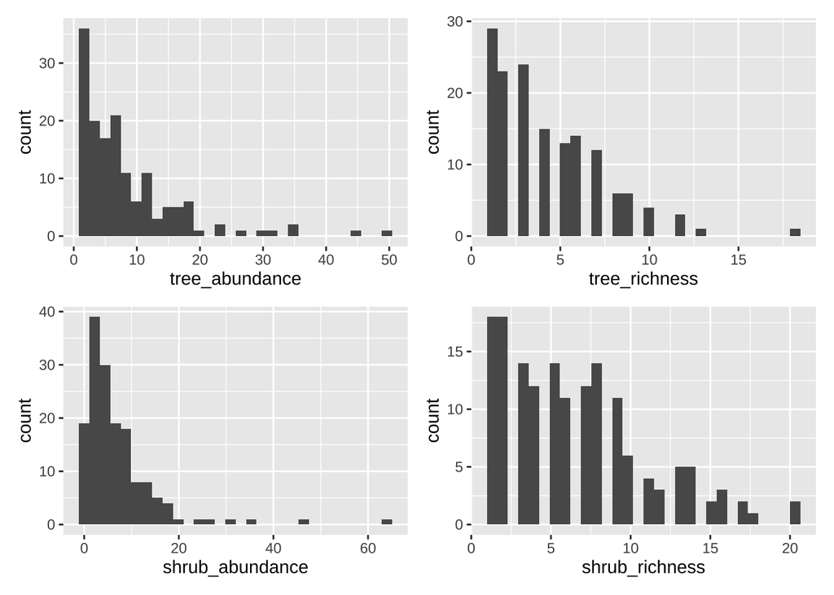

## 相关分析

根据讨论，把Shannon指数结果去除，并且做出表格（见Excel文件）。此处仍然附上图片以供内部参考。

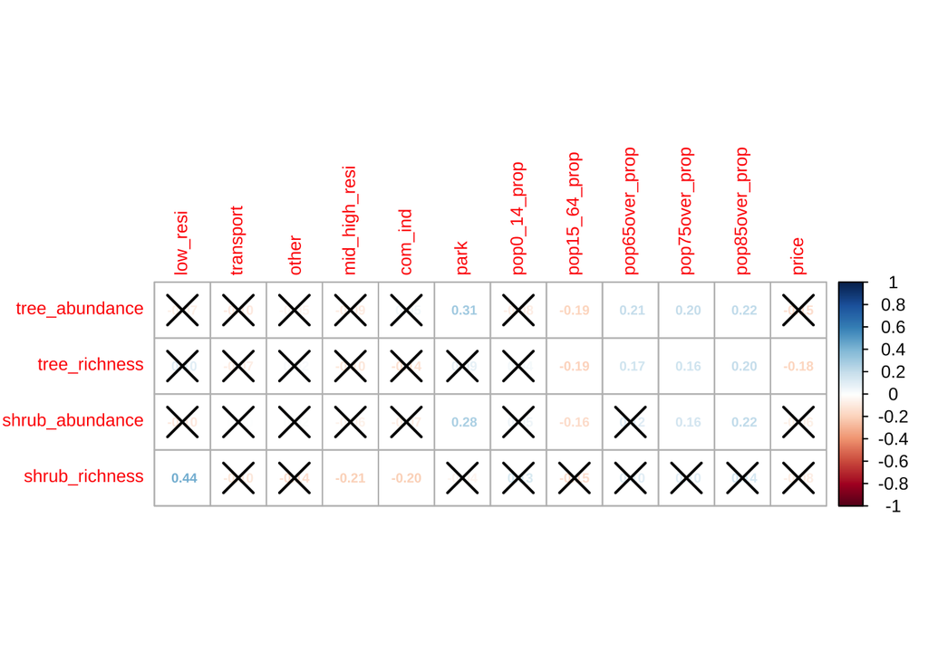

## GLM模型

当然，相关分析仅考虑了一对变量之间的关系，而没有考虑其他变量的影响，因此我们还需要做回归模型分析。回归分析的首要问题是如何选入变量。在本研究中，我们对每个响应变量都测试了所有解释变量组合的模型效果。对于每个被测试的模型，有一个AIC值，AIC值和模型解释变量数量以及模型的拟合程度有关。通常认为AIC越小，模型越好。筛选出来的最佳模型所包含的自变量和AIC见Excel附件。

对于每个模型，我们主要关注estimate（表示解释变量和响应变量之间的正负关系）和p值（表示这种关系是否显著），因此，我提取了上面每个模型所涉及的解释变量的estimate和p值。

| index | model_id | var | estimate | std_error | p |
| --- | --- | --- | --- | --- | --- |
| tree_abundance | 1 | mid_high_resi | -0.2756038 | 0.3025613 | 0.3638797 |
| tree_abundance | 1 | com_ind | 0.4693721 | 0.4139479 | 0.2587374 |
| tree_abundance | 1 | park | 0.7528712 | 0.3105616 | 0.0165896 |
| tree_abundance | 1 | pop65over_prop | 3.2254069 | 2.1080656 | 0.1282181 |
| tree_abundance | 1 | pop75over_prop | -6.7963160 | 4.0782270 | 0.0978052 |
| tree_abundance | 1 | pop85over_prop | 10.3412603 | 5.0716168 | 0.0432874 |
| tree_abundance | 1 | price | -0.0000007 | 0.0000003 | 0.0145663 |
| tree_abundance | 2 | transport | -0.2133512 | 0.3053038 | 0.4858101 |
| tree_abundance | 2 | mid_high_resi | -0.3159889 | 0.3088883 | 0.3080534 |
| tree_abundance | 2 | com_ind | 0.4076228 | 0.4195656 | 0.3329338 |
| tree_abundance | 2 | park | 0.7133326 | 0.3161657 | 0.0255859 |
| tree_abundance | 2 | pop65over_prop | 3.1780568 | 2.1139024 | 0.1349548 |
| tree_abundance | 2 | pop75over_prop | -6.7108146 | 4.0892924 | 0.1029960 |
| tree_abundance | 2 | pop85over_prop | 10.2612240 | 5.0855795 | 0.0455054 |
| tree_abundance | 2 | price | -0.0000007 | 0.0000003 | 0.0143220 |
| tree_abundance | 3 | low_resi | 0.2336286 | 0.2508949 | 0.3533403 |
| tree_abundance | 3 | other | 0.3296509 | 0.3074124 | 0.2853859 |
| tree_abundance | 3 | com_ind | 0.6442613 | 0.4465329 | 0.1512767 |
| tree_abundance | 3 | park | 0.9687877 | 0.3534081 | 0.0069075 |
| tree_abundance | 3 | pop65over_prop | 3.2298890 | 2.1168416 | 0.1292825 |
| tree_abundance | 3 | pop75over_prop | -6.8746693 | 4.0939529 | 0.0953072 |
| tree_abundance | 3 | pop85over_prop | 10.5044844 | 5.0878724 | 0.0407791 |
| tree_abundance | 3 | price | -0.0000008 | 0.0000003 | 0.0120494 |
| tree_abundance | 4 | low_resi | 0.0707228 | 0.2163121 | 0.7441853 |
| tree_abundance | 4 | com_ind | 0.5023069 | 0.4324660 | 0.2473759 |
| tree_abundance | 4 | park | 0.8240226 | 0.3352575 | 0.0151713 |
| tree_abundance | 4 | pop65over_prop | 3.0439886 | 2.1226312 | 0.1537371 |
| tree_abundance | 4 | pop75over_prop | -6.5747886 | 4.1104840 | 0.1119129 |
| tree_abundance | 4 | pop85over_prop | 10.3438376 | 5.0980042 | 0.0443141 |
| tree_abundance | 4 | price | -0.0000007 | 0.0000003 | 0.0197107 |

[output cut: 91 more lines]

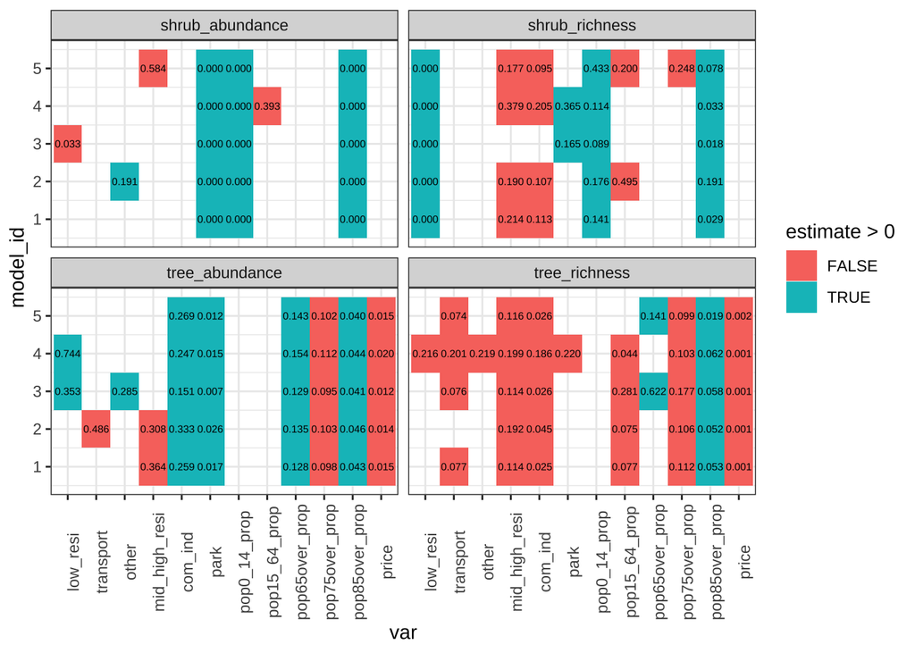

| index | var | model_num | estimate_mean | estimate_mid |
| --- | --- | --- | --- | --- |
| shrub_abundance | low_resi | 3 | -0.1895517 | -0.1895517 |
| shrub_abundance | other | 2 | 0.1466016 | 0.1466016 |
| shrub_abundance | mid_high_resi | 5 | -0.0703905 | -0.0703905 |
| shrub_abundance | park | 5 | 0.9703179 | 0.9835803 |
| shrub_abundance | pop0_14_prop | 5 | 5.3506686 | 5.3226608 |
| shrub_abundance | pop15_64_prop | 4 | -0.4559067 | -0.4559067 |
| shrub_abundance | pop85over_prop | 5 | 5.6457866 | 5.7376276 |
| shrub_richness | low_resi | 5 | 0.7343557 | 0.6865358 |
| shrub_richness | mid_high_resi | 5 | -0.2572158 | -0.2722116 |
| shrub_richness | com_ind | 5 | -0.4069947 | -0.4199643 |
| shrub_richness | park | 4 | 0.2908438 | 0.2908438 |
| shrub_richness | pop0_14_prop | 5 | 1.8229520 | 1.9027329 |
| shrub_richness | pop15_64_prop | 5 | -1.0214108 | -1.0214108 |
| shrub_richness | pop75over_prop | 5 | -2.1636341 | -2.1636341 |
| shrub_richness | pop85over_prop | 5 | 3.8754006 | 3.6929086 |
| tree_abundance | low_resi | 4 | 0.1521757 | 0.1521757 |
| tree_abundance | transport | 2 | -0.2133512 | -0.2133512 |
| tree_abundance | other | 3 | 0.3296509 | 0.3296509 |
| tree_abundance | mid_high_resi | 2 | -0.2957963 | -0.2957963 |
| tree_abundance | com_ind | 5 | 0.4965958 | 0.4693721 |
| tree_abundance | park | 5 | 0.8086780 | 0.7843759 |
| tree_abundance | pop65over_prop | 5 | 3.1581033 | 3.1780568 |
| tree_abundance | pop75over_prop | 5 | -6.7383723 | -6.7352730 |
| tree_abundance | pop85over_prop | 5 | 10.3974314 | 10.3438376 |
| tree_abundance | price | 5 | -0.0000007 | -0.0000007 |
| tree_richness | low_resi | 4 | -9.7774471 | -9.7774471 |
| tree_richness | transport | 5 | -2.8407446 | -0.4134598 |
| tree_richness | other | 4 | -9.7110444 | -9.7110444 |
| tree_richness | mid_high_resi | 5 | -2.3186721 | -0.3717963 |
| tree_richness | com_ind | 5 | -2.6490194 | -0.7166436 |
| tree_richness | park | 4 | -9.7010045 | -9.7010045 |
| tree_richness | pop15_64_prop | 4 | -2.3157954 | -2.3681312 |
| tree_richness | pop65over_prop | 5 | 1.6993210 | 1.6993210 |
| tree_richness | pop75over_prop | 5 | -3.7667770 | -3.2055196 |
| tree_richness | pop85over_prop | 5 | 7.3780729 | 6.7472647 |
| tree_richness | price | 5 | -0.0000008 | -0.0000008 |

将该表格信息可视化出来，方便写作。

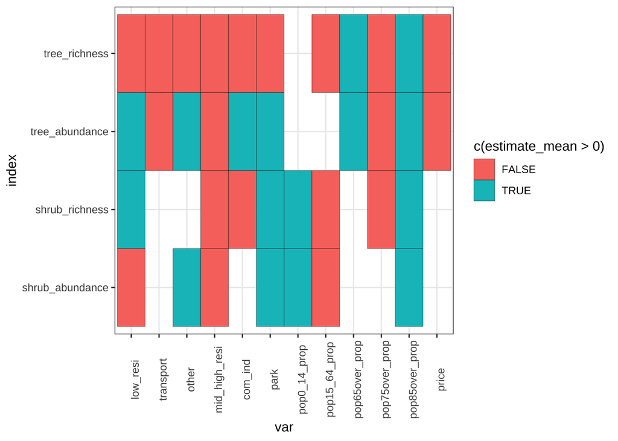